# Classifying Athlete Performance from Historical Olympic Competitions

CMSC320: Introduction to Data Science Spring 2026 Final Project

[output not shown]

## 2. Introduction

The Olympic Games bring together thousands of athletes from over 200 countries every four years. With over 126 years of recorded history, the dataset of Olympic results is large enough to ask data driven questions about what separates medalists from non-medalists. This project attempts to do that.

The central question is can we predict whether an Olympic athlete will win a medal based on their physical profile, demographic background, and event? We use a dataset of over 155,000 athlete biographies and event results spanning Athens 1896 through Tokyo 2020 to build and evaluate a classification model for this task.

Our analysis proceeds in three stages. First, we conduct exploratory data analysis and hypothesis testing to identify whether specific factors, host nation status, athlete sex, and event structure, have statistically measurable relationships with medal outcomes. Second, we engineer features from the raw data and build a classification pipeline using several standard models, evaluating performance under stratified cross-validation. Third, we interpret the results.

## 3. Data Curation

Our dataset is sourced from Kaggle: [126 Years of Historical Olympic Dataset](https://www.kaggle.com/datasets/muhammadehsan02/126-years-of-historical-olympic-dataset). It comprises six CSV files covering every Olympic Games from Athens 1896 through Tokyo 2020/Beijing 2022.

The files we use are: `Olympic_Athlete_Biography.csv` (155,861 athletes with height, weight, country, and birth date), `Olympic_Athlete_Event_Details.csv` (per-athlete event entries with medal outcomes and team sport flags), `Olympic_Games_Summary.csv` (edition metadata including year), and `Olympic_Country_Profiles.csv` (NOC-to-country name mapping).

Several preprocessing steps were required before analysis. First, we merged the biography, event, and games tables on *'athlete_id'* and *'edition_id'* to produce a single denormalized record per athlete-event appearance. Second, weight values were stored as both single numbers and ranges (e.g.,"69-77"); we converted ranges to their midpoint mean and coerced all values to float. Third, birth dates were parsed to datetime with error coercion. Fourth, we dropped all records prior to 1960, since height and weight missingness exceeded 45% for those years, imputing that many values would bias the physical attribute features we rely on for ML. Finally, remaining missing heights and weights were imputed with the per-sex, per-sport mean, with a global mean fallback for any residual nulls. The result is *'biography_pruned'* which is a clean DataFrame of athlete-event appearances from 1960-2022 ready for EDA and modeling.

```
COUNTRIES

SHAPE: (235, 2)

DATASET INFORMATION:
<class 'pandas.DataFrame'>
RangeIndex: 235 entries, 0 to 234
Data columns (total 2 columns):
 #   Column   Non-Null Count  Dtype
---  ------   --------------  -----
 0   noc      235 non-null    str
 1   country  235 non-null    str
dtypes: str(2)
memory usage: 3.8 KB
None

DESCRIPTIVE STATISTICS:
        noc      country
count   235          235
unique  234          235
top     ROC  Afghanistan
freq      2            1

MISSING VALUES:
noc        0
country    0
dtype: int64

BIOGRAPHIES

SHAPE: (155861, 10)

DATASET INFORMATION:
<class 'pandas.DataFrame'>
RangeIndex: 155861 entries, 0 to 155860
Data columns (total 10 columns):
 #   Column         Non-Null Count   Dtype
---  ------         --------------   -----
 0   athlete_id     155861 non-null  int64
 1   name           155861 non-null  str
```

[output cut: 228 more lines]

```
max    372.000000  2032.000000

MISSING VALUES:
edition              0
edition_id           0
edition_url          0
year                 0
city                 0
country_flag_url     0
country_noc          0
start_date           9
end_date            10
competition_date     0
isHeld              59
dtype: int64
```

### Events (events_df) and Olympic (olympics_df) data cleaning

*events_df* holds information about the edition of the Games, sport, event specifics and information on the athlete's performance, including their position, medal won, and whether the event was a team sport.

*olympics_df* holds information about the Olympic Games edition, year hosted, host city, country, URLS for edition and country flags, and dates for the start, end, and competition periods

This section cleans the Olympic and Events datasets so they are easier to analyze and merge. Missing values in the *`medal`* column are filled with "No Medal" because blank medal entries represent athletes who did not win a medal. This also makes the column easier to convert into a binary target variable later. Olympic Games that were not held due to war are removed because they do not contain real competition results. After that, unnecessary or duplicate columns, such as *'country_flag_url'* and repeated *'country_noc'* columns, are dropped to simplify the datasets. We also converted the start and end date columns into date time and deleted any future games that havent happened yet. Finally, the events dataset is merged with the countries dataset so each event record includes the full country name instead of only the NOC code.

### Biography (biography_df) Data Cleaning

*biography_df* holds athlete information like name, sex, birth date, height, weight, and country

```
<StringArray>
[      nan,   '58-60',   '48-57',   '69-77',   '70-83',   '59-60', '110-123',
   '74-77',   '75-77',  '90-121',
 ...
 '142-151',   '48-63',   '64-73',   '87-89',   '65-72',   '85-86',  '97-103',
 '121-126', '106-111',   '83-95']
Length: 436, dtype: str
```

The *`weight`* column as shown above needs to be cleaned because some values are as strings, some contained extra spacing characters, and some were written as ranges instead of single numbers. So we format it correctly by:

1. Extracting the integers from the string

2. Replacing the range with the mean from the range

```
array([ 55. ,  70. ,   nan,  68. ,  58. ,  76. ,  75. ,  97. ,  56. ,
        65. ,  85. ,  86. ,  67. ,  81. ,  63. ,  79. ,  45. ,  71. ,
        54. ,  78. ,  66. ,  51. ,  61. , 100. ,  93. ,  60. ,  89. ,
        64. ,  57. ,  77. ,  88. ,  49. ,  59. ,  99. ,  94. ,  80. ,
        50. ,  69. ,  84. ,  98. ,  82. ,  72. ,  95. ,  90. ,  53. ,
        91. ,  87. ,  74. ,  83. , 142. ,  62. ,  73. ,  52. ,  42. ,
       107. , 110. ,  92. , 117. ,  48. ,  52.5,  44. , 105. ,  47. ,
       109. , 103. ,  40. , 130. , 115. ,  96. ,  32. , 144. , 102. ,
        43. , 124. , 126. , 104. , 125. , 118. ,  76.5,  34. , 140. ,
        59.5, 116.5,  75.5, 120. ,  46. , 127. , 112. , 105.5, 101. ,
       150. , 122. ,  82.5, 159. , 108. ,  41. ,  38. ,  69.5, 113. ,
       123. ,  61.5, 127.5,  65.5, 176.5,  85.5,  74.5,  73.5,  72.5,
       137. ,  68.5, 148. , 106. ,  55.5, 134. ,  56.5, 141. , 111. ,
        77.5,  36. , 116. ,  80.5,  67.5, 154. ,  37. , 128. ,  33. ,
       145. , 135. , 119. ,  35. ,  84.5,  70.5,  96.5,  91.5,  39. ,
       139. , 114. ,  88.5, 106.5, 138. , 143. ,  93.5,  78.5,  66.5,
       121. ,  79.5,  92.5, 131. ,  53.5, 133. ,  64.5,  97.5,  98.5,
        60.5,  81.5, 146. ,  86.5,  54.5,  31. , 121.5,  83.5, 112.5,
       138.5, 190. ,  89.5, 129. , 150.5, 161. , 136. ,  63.5,  62.5,
       165. , 102.5,  28. , 152. ,  71.5,  58.5, 132. , 117.5, 129.5,
       157.5, 158. , 163. , 147. , 100.5,  87.5,  30. ,  49.5, 107.5,
       118.5,  94.5, 156. , 178. , 175. , 160. , 133.5, 180. , 155. ,
       131.5,  48.5, 103.5, 167. ,  57.5, 214. , 109.5, 198. ,  51.5,
       130.5,  90.5, 182. , 122.5, 151. , 135.5, 101.5, 137.5, 170. ,
       149. , 104.5,  25. , 146.5, 123.5, 108.5])
```

[output not shown]

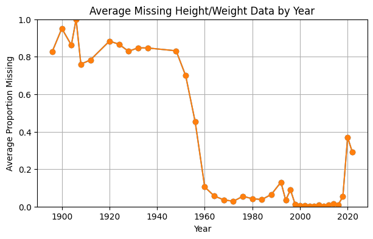

Because records before 1960 contain a higher proportion of missing height and weight values, we removed those earlier years from the dataset. This helps create a cleaner dataset for later visualizations and machine learning analysis.

We chose not to impute the missing height and weight values because the missingness is not random. Most missing values occur before 1960, which shows that older Olympic records were less complete. Imputing those with an average could introduce artificial data and bias the analysis, so we chose to prune the dataset to include records from 1960 onward instead of relying on large amounts of imputed values (since over half the data for height and weight were missing for those years).

## 4. Exploratory Data Analysis

Before building a predictive model, we need to understand the structure of the data. Our EDA pursues three questions: (1) Do host nations win more medals than they do when competing abroad? (2) Has female athlete representation at the Olympics increased significantly over time? (3) In mixed-gender events, do men and women win medals at equal rates?

### Group by summer/winter, gender, etc.

```
difference in gender counts:
 sex
Male      161899
Female     84479
Name: count, dtype: int64

difference in mean by height/weight:
             height     weight
sex
Female  168.014079  60.264195
Male    179.232675  76.079029

difference in median by height/weight:
         height  weight
sex
Female   168.0    60.0
Male     180.0    75.0

sports with big gender diff:  sex             Female  Male  diff
sport
3x3 Basketball      32    32     0
Golf               120   120     0
Trampolining        92    92     0
Surfing             20    20     0
Sport Climbing      20    20     0

highest attending countries:  country
United States                          14745
Canada                                  9716
Italy                                   9161
Japan                                   8994
France                                  8843
                                       ...
Denmark  Great Britain                     1
Kazakhstan  ROC  Russian Federation        1
Cuba  Poland                               1
Germany  Iceland  Japan                    1
Azerbaijan  Bulgaria                       1
Length: 668, dtype: int64

highest medaling countries:  country
United States                                                  4207
Soviet Union                                                   1937
Germany                                                        1514
Australia                                                      1318
Canada                                                         1279
                                                               ...
Panama                                                            1
Georgia  Serbia                                                   1
Norway  Sweden                                                    1
Georgia  Soviet Union  United States                              1
Independent Olympic Athletes  Serbia  Serbia and Montenegro       1
Name: medal, Length: 369, dtype: int64
```

### Conclusion #1 - Home Field Advantage For Medals

Testing to see whether or not a host country has an advantage for winning medals by comparing their home performance to their away performance. Medals include bronze, silver, and gold.

```
     country  avg_medals_home  avg_medals_away
0  Australia             46.5        14.242424
1    Austria              9.0         7.145833
2    Belgium             42.0         4.212121
3     Brazil             19.0         6.894737
4     Canada             14.0        10.428571
Number of countries tested: 25
Average Medals HOME: 37.76
Average Medals AWAY: 16.95
T-statistic: 3.6261
P-value: 0.00135
```

Graph the results using horizontal lines to better represent the home field advantage when it comes to medals

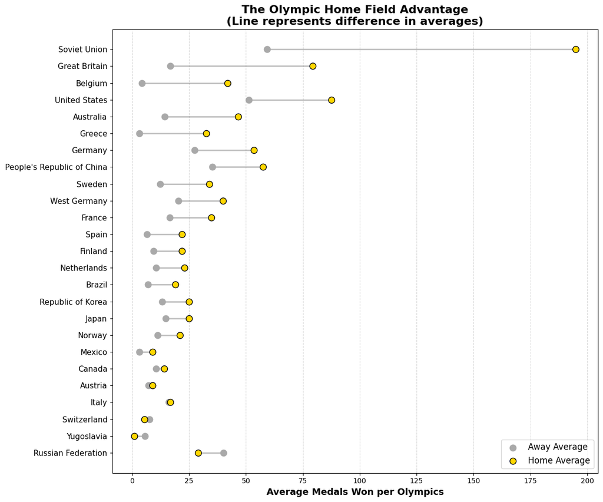

Note that some countries have marginal advantages or away advantages (Switzerland and Yugoslavia, for example)

### Conclusion #2 - The inclusion of Female Athletes Over Time

Testing to see how the proportion of female athletes at the Olympics has changed since 1960, separately for Summer and Winter Games. A statistically significant upward trend would suggest the Olympics have become meaningfully more gender inclusive over time.

```
Summer Games  — trend: +0.66% female athletes per year  (p = 0.00000)
Winter Games  — trend: +0.47% female athletes per year  (p = 0.00000)
```

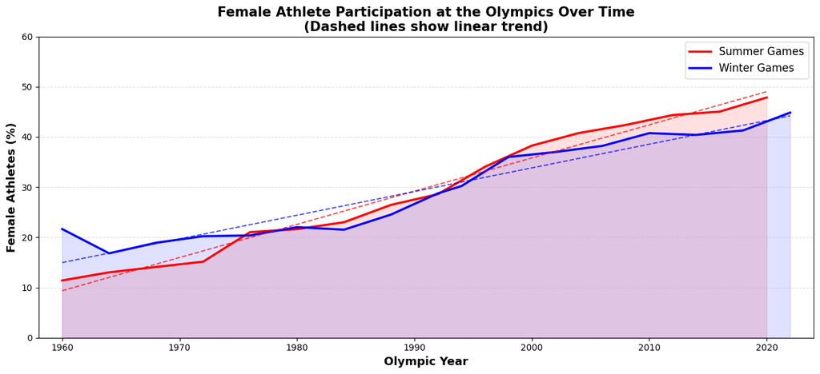

### Conclusion #3 – Olympic medals won by athlete sex in mixed events

We tested whether athlete sex was a statistically significant influence to win medals in mixed-gender Olympic events.

```
DATAFRAME
Olympic medals won by sex in mixed events
```

| sex event | Female | Male |
| --- | --- | --- |
| 2 × 6 kilometres and 2 × 7.5 kilometres Relay, Mixed | 14 | 14 |
| 2,000 metres Relay, Mixed | 8 | 8 |
| 4 × 100 metres Medley Relay, Mixed | 9 | 7 |
| 4 × 400 metres Relay, Mixed | 12 | 12 |
| Air Pistol, 10 metres, Team, Mixed | 3 | 3 |
| Air Rifle, 10 metres, Team, Mixed | 3 | 3 |
| Doubles, Covered Courts, Mixed | 3 | 3 |
| Doubles, Mixed | 43 | 44 |
| Ice Dancing, Mixed | 27 | 26 |
| Mixed Doubles, Mixed | 5 | 5 |
| Multihull, Mixed | 6 | 6 |
| Normal Hill, Team, Mixed | 6 | 6 |
| Pairs, Mixed | 58 | 60 |
| Relay, Mixed | 6 | 6 |
| Team Aerials, Mixed | 3 | 6 |
| Team Cross, Mixed | 3 | 3 |
| Team Relay, Mixed | 5 | 22 |
| Team, Mixed | 90 | 90 |
| Trap, Team, Mixed | 3 | 3 |

```
HYPOTHESES
H(0): Men and women win equal medals on average in mixed Olympic events.
H(1): Men and women do not win equal medals on average in mixed Olympic events.

BINOMIAL TEST
Expected proportion: 0.5
Actual proportion: 0.5117719950433705
p-value: 0.5263479521745558

Because the p-value is greater than 0.05, we do not reject H(0). There is no gender imbalance in medal-winning athletes for mixed Olympic sports.

PLOT
```

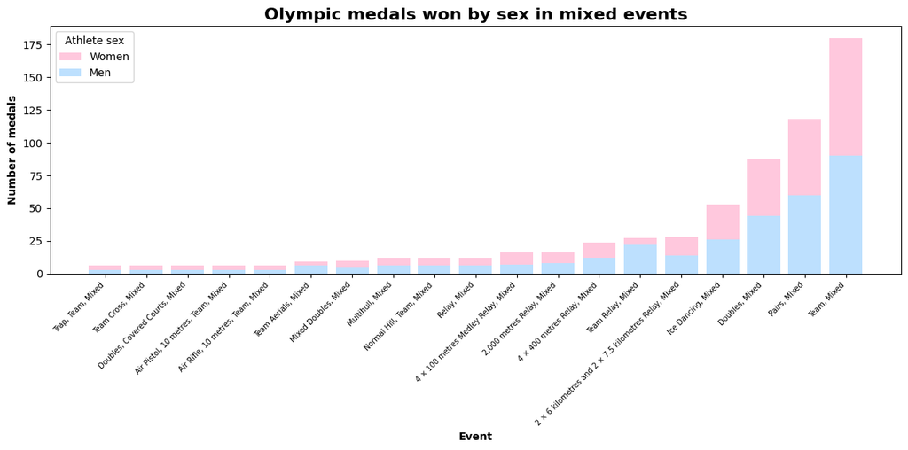

# 5. Primary Analysis

## 5.1 Machine Learning Design & Development

### *Goal: Figure out whether an athlete can win a medal in their event*

```
Rows available for ML: 244,783
Medal rate: 0.136
medal_won
No Medal    0.864
Medal       0.136
```

## 5.2 Algorithm Training & Test Data Analysis

```
Feature matrix: 244,783 rows x 12 columns
Medals (positive class): 33,309 / 244,783 (13.6%)

  height                  dtype=float64     nulls=0
  weight                  dtype=float64     nulls=0
  year                    dtype=int64       nulls=0
  sex                     dtype=int64       nulls=0
  isTeamSport             dtype=int64       nulls=0
  age                     dtype=float64     nulls=0
  prior_appearances       dtype=int64       nulls=0
  prior_medals            dtype=int64       nulls=0
  event_medal_rate        dtype=float64     nulls=0
  event_avg_size          dtype=float64     nulls=0
  country                 dtype=str         nulls=0
  sport                   dtype=str         nulls=0
```

Ensuring no NaNs that can affect model fitting in the following step

```
Train: 195,826  |  Test: 48,957
  Training Logistic Regression...
    CV F1: 0.4182
  Training Decision Tree...
    CV F1: 0.4213
  Training Extra Trees...
    CV F1: 0.4164
  Training Random Forest...
    CV F1: 0.4645
  Training Hist Gradient Boosting...
    CV F1: 0.4535

Cross-Validation Results (5-fold)
```

| Model | Accuracy | Precision | Recall | F1 |
| --- | --- | --- | --- | --- |
| Random Forest | 0.7717 | 0.3411 | 0.7277 | 0.4645 |
| Hist Gradient Boosting | 0.7470 | 0.3211 | 0.7715 | 0.4535 |
| Decision Tree | 0.7105 | 0.2894 | 0.7745 | 0.4213 |
| Logistic Regression | 0.7317 | 0.2966 | 0.7088 | 0.4182 |
| Extra Trees | 0.7169 | 0.2894 | 0.7424 | 0.4164 |

## 6. Visualization and Result Analysis

We produce four visualizations that together explain both how well the model predicts and what it learned:

Confusion Matrix: counts predictions against ground truth on the held-out test set. The off-diagonal cells show the cost of each type of mistake: false positives (non-medalists the model flagged) vs. false negatives (medalists the model missed).

Precision-Recall Curve: shows the tradeoff between precision and recall at every possible decision threshold. Moving the threshold down catches more medalists (higher recall) but also increases false alarms (lower precision). The red dot marks the threshold that maximizes F1.

Feature Importances: ranks each input by its average decrease in node impurity across all trees. Engineered features are highlighted in orange to show their incremental contribution over the original biographic attributes.

ROC Curves: plots True Positive Rate vs. False Positive Rate for all five classifiers on the same axes. AUC summarizes discriminative ability independent of threshold: AUC = 0.5 is random chance, AUC = 1.0 is perfect.`

```
Best model by CV F1: Random Forest

Test Set Performance — All Models
```

| Model | Accuracy | Precision | Recall | F1 |
| --- | --- | --- | --- | --- |
| Random Forest | 0.7665 | 0.3371 | 0.7406 | 0.4633 |
| Hist Gradient Boosting | 0.7490 | 0.3248 | 0.7826 | 0.4590 |
| Decision Tree | 0.7128 | 0.2916 | 0.7771 | 0.4241 |
| Logistic Regression | 0.7310 | 0.2964 | 0.7109 | 0.4184 |
| Extra Trees | 0.7186 | 0.2906 | 0.7408 | 0.4174 |

```
Classification Report: Random Forest
              precision    recall  f1-score   support

    No Medal       0.95      0.77      0.85     42295
       Medal       0.34      0.74      0.46      6662

    accuracy                           0.77     48957
   macro avg       0.64      0.76      0.66     48957
weighted avg       0.87      0.77      0.80     48957
```

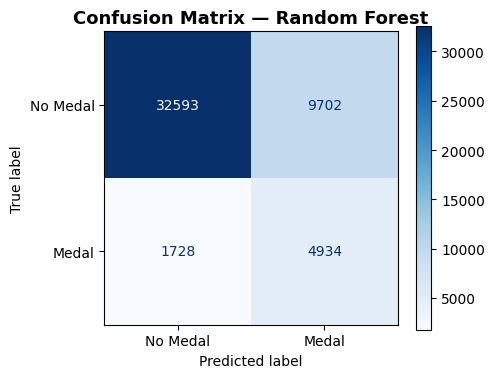

Confusion matrix here confirms what we've been saying: there are clearly more "no medal" classifications given out. This is true as there are generally less people that receive medals, but it leaves room for class imbalances and biases when training.

```
default threshold (0.5) F1:  0.4633
optimal threshold:           0.655
optimal threshold F1:        0.5057

              precision    recall  f1-score   support

    No Medal       0.92      0.92      0.92     42295
       Medal       0.50      0.51      0.51      6662

    accuracy                           0.86     48957
   macro avg       0.71      0.72      0.71     48957
weighted avg       0.87      0.86      0.86     48957
```

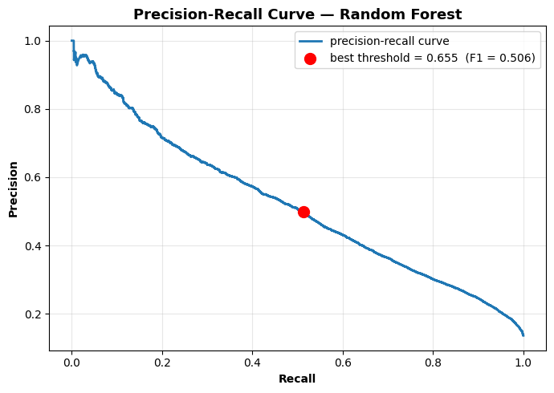

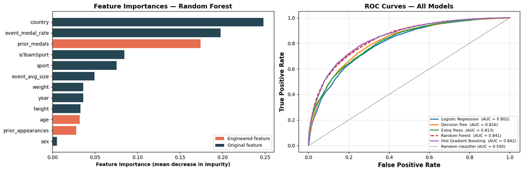

## Conclusion

This project analyzed 126 years of Olympic data to predict whether an athlete would win a medal based on their physical profile, country of origin, sport, and event. The analysis covered three stages: exploratory data analysis with hypothesis testing, feature engineering, and a multi-model classification pipeline.